# Fitting a Multiple Linear Model in F1 data to predict Fastest Lap Speed.

Alex Gichuki

2023-04-08

```r
# Setup

library(tidyverse)
library(tidymodels)
library(kableExtra)
library(psych)
library(GGally)
library(ggfortify)
library(car)
```

Reading the clean F1 data. Working with data from race 841 to race 1046 for all drivers who completed the race.

```r
# Reading the full data
f1_full_df <- read.csv("Formula_One.csv")

# Creating a subset data set: removing driverId from the f1_full_df
f1_df <- f1_full_df %>%
  select(-driverId)

# Glance at the dataset
kable(head(f1_df))
```

| raceId | circuitId | grid | finishingPosition | points | laps | raceDuration | rank | fastestLapSpeed | altitude | averagePitstopDuration | averageLapDuration | fastestLapDuration |
| --- | --- | --- | --- | --- | --- | --- | --- | --- | --- | --- | --- | --- |
| 841 | 1 | 1 | 1 | 25 | 58 | 5370259 | 4 | 212.488 | 10 | 23319.50 | 92590.67 | 89844 |
| 841 | 1 | 2 | 2 | 18 | 58 | 5392556 | 8 | 211.382 | 10 | 23213.00 | 92975.10 | 90314 |
| 841 | 1 | 6 | 3 | 15 | 58 | 5400819 | 7 | 211.969 | 10 | 25109.00 | 93117.57 | 90064 |
| 841 | 1 | 5 | 4 | 12 | 58 | 5402031 | 2 | 213.336 | 10 | 24055.00 | 93138.47 | 89487 |
| 841 | 1 | 3 | 5 | 10 | 58 | 5408430 | 3 | 213.066 | 10 | 24058.67 | 93248.79 | 89600 |
| 841 | 1 | 4 | 6 | 8 | 58 | 5424563 | 5 | 212.396 | 10 | 20950.33 | 93526.95 | 89883 |

Specifying the categorical variables

```r
# Convert the following variables to categorical variables using as.factor()
f1_df$raceId <- as.factor(f1_df$raceId)
f1_df$circuitId <- as.factor(f1_df$circuitId)
f1_df$grid <- as.factor(f1_df$grid)
f1_df$finishingPosition <- as.factor(f1_df$finishingPosition)
f1_df$rank <- as.factor(f1_df$rank)
```

Evaluating the data before fitting the model

```r
kable(summary(f1_df))
```

|  | raceId | circuitId | grid | finishingPosition | points | laps | raceDuration | rank | fastestLapSpeed | altitude | averagePitstopDuration | averageLapDuration | fastestLapDuration |
| --- | --- | --- | --- | --- | --- | --- | --- | --- | --- | --- | --- | --- | --- |
|  | 855 : 19 | 9 : 145 | 1 : 190 | 1 :208 | Min. : 0.00 | Min. :43.00 | Min. : 4526665 | 2 : 195 | Min. :148.6 | Min. : -7.0 | Min. : 17349 | Min. : 62932 | Min. : 55404 |
|  | 991 : 19 | 13 : 133 | 2 : 183 | 2 :208 | 1st Qu.: 2.00 | 1st Qu.:53.00 | 1st Qu.: 5426327 | 1 : 193 | 1st Qu.:193.3 | 1st Qu.: 7.0 | 1st Qu.: 21919 | 1st Qu.: 89108 | 1st Qu.: 82450 |
|  | 887 : 18 | 3 : 121 | 3 : 182 | 3 :208 | Median : 8.00 | Median :57.00 | Median : 5767019 | 3 : 184 | Median :205.1 | Median : 45.0 | Median : 23624 | Median :101649 | Median : 94485 |
|  | 862 : 17 | 15 : 109 | 4 : 168 | 4 :204 | Mean : 9.47 | Mean :59.35 | Mean : 6005680 | 4 : 178 | Mean :204.4 | Mean : 191.8 | Mean : 68089 | Mean :102414 | Mean : 92589 |
|  | 877 : 17 | 17 : 108 | 5 : 147 | 5 :195 | 3rd Qu.:15.00 | 3rd Qu.:66.00 | 3rd Qu.: 6185797 | 5 : 164 | 3rd Qu.:219.0 | 3rd Qu.: 162.0 | 3rd Qu.: 26934 | 3rd Qu.:109279 | 3rd Qu.:101932 |
|  | 894 : 17 | 24 : 106 | 6 : 141 | 6 :186 | Max. :50.00 | Max. :87.00 | Max. :14743144 | 6 : 150 | Max. :255.0 | Max. :2227.0 | Max. :1747072 | Max. :210616 | Max. :116486 |
|  | (Other):2010 | (Other):1395 | (Other):1106 | (Other):908 | NA | NA | NA | (Other):1053 | NA | NA | NA | NA | NA |

Creating a Scatter plot Matrix to evaluate correlations

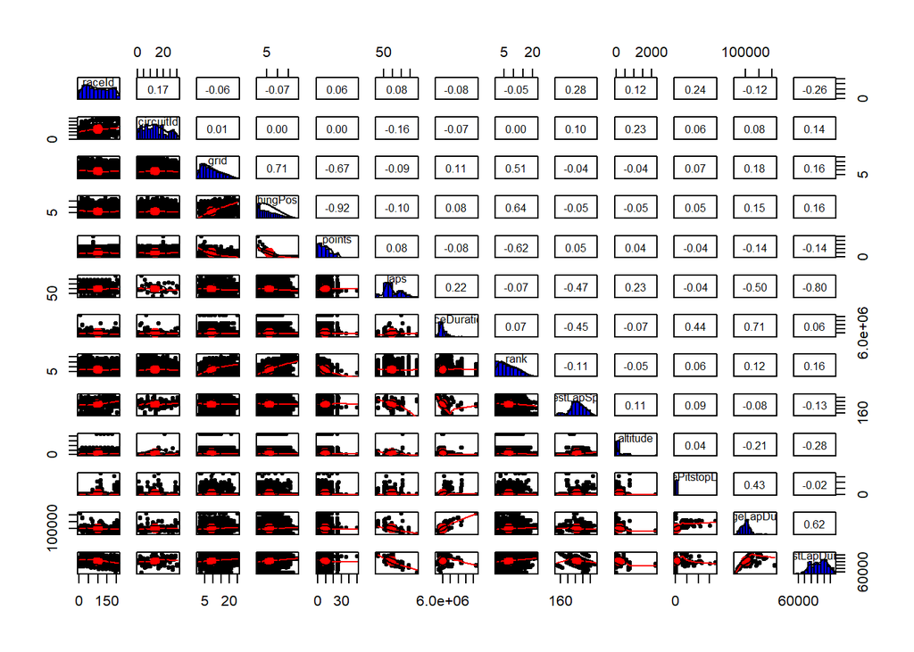

```r
pairs.panels(
  f1_df,
  hist.col = "blue",
  method= "pearson",
  density = TRUE,
  ellipses = TRUE
)
```

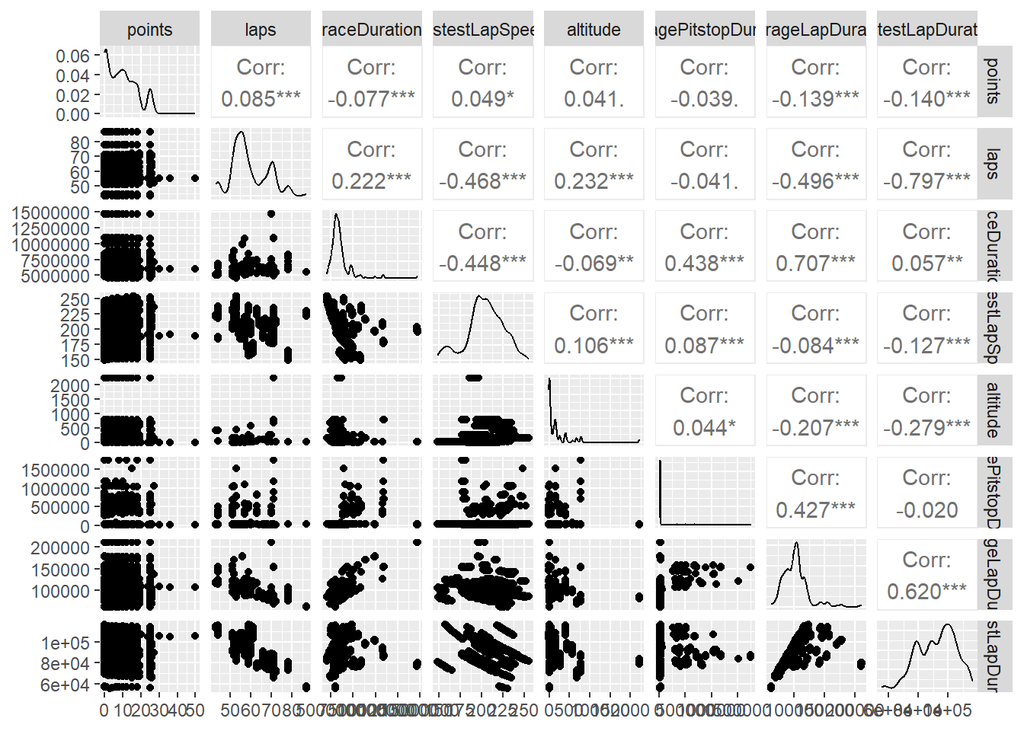

```r
# Creating a list with continous variables to evaluate correlations
cont_vars <- c("points", "laps", "raceDuration", "fastestLapSpeed", "altitude",
               "averagePitstopDuration", "averageLapDuration", "fastestLapDuration")

# Create scatterplot matrix using ggpairs for continuous variables
ggpairs(data = f1_df[, cont_vars])
```

model1 = Using all variables

```r
# Fitting a linear model in all variables to predict Fastest Lap Speed
model1 <- lm(fastestLapSpeed ~ raceId + circuitId + grid + finishingPosition +
                  points + laps + raceDuration + rank + altitude + fastestLapDuration +
               averageLapDuration + averagePitstopDuration, data = f1_df)

tidy(model1)
```

| term | estimate | std.error | statistic | p.value |
| --- | --- | --- | --- | --- |
| (Intercept) | 3.723314e+02 | 3.676941e+00 | 101.26117888 | 0.000000e+00 |
| raceId842 | 4.509409e+00 | 5.026297e-01 | 8.97163310 | 7.016861e-19 |
| raceId843 | 1.495968e+00 | 4.759307e-01 | 3.14324633 | 1.697481e-03 |
| raceId844 | 1.065721e+00 | 1.641964e-01 | 6.49052490 | 1.096766e-10 |
| raceId845 | -2.365035e+01 | 1.124630e+00 | -21.02944385 | 3.635466e-88 |
| raceId846 | -7.997381e+01 | 3.252617e+00 | -24.58752578 | 1.132657e-115 |
| raceId847 | -5.809546e+01 | 6.727294e+00 | -8.63578451 | 1.241174e-17 |
| raceId848 | 2.855135e-01 | 5.022888e-01 | 0.56842496 | 5.698158e-01 |
| raceId849 | 1.732362e+01 | 9.202477e-01 | 18.82495503 | 1.935014e-72 |
| raceId850 | -7.793233e+00 | 4.576138e-01 | -17.03015204 | 1.648168e-60 |

[output cut: 298 more lines]

Model 1 Summary statistics

```r
glance(model1)
```

| r.squared | adj.r.squared | sigma | statistic | p.value | df | logLik | AIC | BIC | deviance | df.residual | nobs |
| --- | --- | --- | --- | --- | --- | --- | --- | --- | --- | --- | --- |
| 0.9997739 | 0.9997401 | 0.3388739 | 29602.58 | 0 | 275 | -565.1665 | 1684.333 | 3251.531 | 211.4122 | 1841 | 2117 |

The r squared is very high which could suggest over fitting. Additionally the resulting model is very complex due to the categorical variables in the data with many levels. A simpler model would be better.

Fitting model 2: Removing one variable from each variable pair with high correlation. Here I remove averagePitstopDuration and averageLapDuration

```r
model2 <- lm(fastestLapSpeed ~ raceId + circuitId + grid + finishingPosition +
                  points + laps + raceDuration + rank + altitude + fastestLapDuration,
                data = f1_df)

tidy(model2)
```

| term | estimate | std.error | statistic | p.value |
| --- | --- | --- | --- | --- |
| (Intercept) | 3.721949e+02 | 3.691063e+00 | 1.008368e+02 | 0.000000e+00 |
| raceId842 | 5.728528e+00 | 4.087811e-01 | 1.401368e+01 | 1.792793e-42 |
| raceId843 | 2.717478e+00 | 3.747219e-01 | 7.251986e+00 | 6.018542e-13 |
| raceId844 | 1.064661e+00 | 1.648713e-01 | 6.457527e+00 | 1.357638e-10 |
| raceId845 | -2.794940e+01 | 4.213689e-01 | -6.633002e+01 | 0.000000e+00 |
| raceId846 | -9.177788e+01 | 1.544249e+00 | -5.943205e+01 | 0.000000e+00 |
| raceId847 | -7.263865e+01 | 5.741895e+00 | -1.265064e+01 | 3.090636e-35 |
| raceId848 | 8.904665e-01 | 4.826403e-01 | 1.844990e+00 | 6.519935e-02 |
| raceId849 | 2.101010e+01 | 2.194115e-01 | 9.575657e+01 | 0.000000e+00 |
| raceId850 | -8.969758e+00 | 3.584500e-01 | -2.502373e+01 | 3.231651e-119 |

[output cut: 296 more lines]

```r
glance(model2)
```

| r.squared | adj.r.squared | sigma | statistic | p.value | df | logLik | AIC | BIC | deviance | df.residual | nobs |
| --- | --- | --- | --- | --- | --- | --- | --- | --- | --- | --- | --- |
| 0.9997718 | 0.999738 | 0.3402734 | 29574.6 | 0 | 273 | -575.0408 | 1700.082 | 3255.964 | 213.3936 | 1843 | 2117 |

This model reduces the r squared by a little bit. But the model is still complex.

Fitting Model 3: How about removing race id

```r
# Fitting a linear model in all variables except race id to predict Fastest Lap Speed
model3 <- lm(fastestLapSpeed ~ circuitId + grid + finishingPosition +
                  points + laps + raceDuration + rank + altitude + fastestLapDuration +
               averageLapDuration + averagePitstopDuration, data = f1_df)

tidy(model3)
```

| term | estimate | std.error | statistic | p.value |
| --- | --- | --- | --- | --- |
| (Intercept) | 5.342308e+02 | 2.521893e+00 | 2.118372e+02 | 0.000000e+00 |
| circuitId2 | 6.860154e+00 | 2.635776e-01 | 2.602707e+01 | 5.274919e-129 |
| circuitId3 | 1.730827e+00 | 2.201560e-01 | 7.861822e+00 | 6.112316e-15 |
| circuitId4 | -8.673097e+00 | 2.619902e-01 | -3.310466e+01 | 2.582753e-192 |
| circuitId5 | 2.158893e+00 | 3.494692e-01 | 6.177633e+00 | 7.849273e-10 |
| circuitId6 | -4.321983e+01 | 3.762589e-01 | -1.148673e+02 | 0.000000e+00 |
| circuitId7 | -1.197246e+01 | 2.819337e-01 | -4.246552e+01 | 4.577153e-282 |
| circuitId9 | 1.117709e+01 | 2.180482e-01 | 5.125973e+01 | 0.000000e+00 |
| circuitId10 | -1.039156e+01 | 2.694709e-01 | -3.856282e+01 | 3.365050e-244 |
| circuitId11 | -1.298076e+01 | 2.939708e-01 | -4.415664e+01 | 1.483901e-298 |

[output cut: 91 more lines]

```r
glance(model3)
```

| r.squared | adj.r.squared | sigma | statistic | p.value | df | logLik | AIC | BIC | deviance | df.residual | nobs |
| --- | --- | --- | --- | --- | --- | --- | --- | --- | --- | --- | --- |
| 0.9956394 | 0.9954253 | 1.421807 | 4651.811 | 0 | 99 | -3697.707 | 7597.414 | 8168.847 | 4077.438 | 2017 | 2117 |

Has high R squared but still the model is complex to interpret.

Fitting model 4: Fitting a model without specifying race Id and circuit Id

```r
# Fitting a linear model without specifying race Id and Circuit ID to predict Fastest Lap Speed
model4 <- lm(fastestLapSpeed ~ grid + finishingPosition +
                  points + laps + raceDuration + rank + altitude + fastestLapDuration +
               averageLapDuration + averagePitstopDuration, data = f1_df)

tidy(model4)
```

| term | estimate | std.error | statistic | p.value |
| --- | --- | --- | --- | --- |
| (Intercept) | 6.142154e+02 | 6.573291e+00 | 93.44108787 | 0.000000e+00 |
| grid1 | 4.480685e+00 | 3.219906e+00 | 1.39155771 | 1.642076e-01 |
| grid2 | 4.112473e+00 | 3.207848e+00 | 1.28200357 | 1.999866e-01 |
| grid3 | 4.189320e+00 | 3.200443e+00 | 1.30898149 | 1.906876e-01 |
| grid4 | 4.181141e+00 | 3.200935e+00 | 1.30622475 | 1.916230e-01 |
| grid5 | 4.253645e+00 | 3.201427e+00 | 1.32867143 | 1.841046e-01 |
| grid6 | 4.596418e+00 | 3.203581e+00 | 1.43477503 | 1.515040e-01 |
| grid7 | 4.811214e+00 | 3.205054e+00 | 1.50113382 | 1.334753e-01 |
| grid8 | 4.475252e+00 | 3.215268e+00 | 1.39187514 | 1.641115e-01 |
| grid9 | 4.078153e+00 | 3.212590e+00 | 1.26942841 | 2.044327e-01 |

[output cut: 61 more lines]

```r
glance(model4)
```

| r.squared | adj.r.squared | sigma | statistic | p.value | df | logLik | AIC | BIC | deviance | df.residual | nobs |
| --- | --- | --- | --- | --- | --- | --- | --- | --- | --- | --- | --- |
| 0.9146567 | 0.9117369 | 6.245255 | 313.2538 | 0 | 70 | -6845.751 | 13835.5 | 14242.86 | 79800.58 | 2046 | 2117 |

The resulting model has a significantly lower R squared than the previous 3 models, and is lesser complex 3 models. But we could do better.

Fitting model 5: Fitting a model that does not include any of the categorical variables: That is a model that does not include raceId, circuit Id, grid, finishingPosition, and rank.

```r
# Fitting a linear model without any of the categorical variables predict Fastest Lap Speed
model5 <- lm(fastestLapSpeed ~ points + laps + raceDuration +  altitude + fastestLapDuration +
               averageLapDuration + averagePitstopDuration, data = f1_df)

tidy(model5)
```

| term | estimate | std.error | statistic | p.value |
| --- | --- | --- | --- | --- |
| (Intercept) | 6.197824e+02 | 4.111012e+00 | 150.7615266 | 0.000000e+00 |
| points | -2.670302e-02 | 1.743921e-02 | -1.5312059 | 1.258685e-01 |
| laps | -3.400933e+00 | 5.098050e-02 | -66.7104699 | 0.000000e+00 |
| raceDuration | -3.276077e-06 | 4.506326e-07 | -7.2699510 | 5.042177e-13 |
| altitude | 5.248524e-03 | 4.023939e-04 | 13.0432477 | 1.874199e-37 |
| fastestLapDuration | -2.322844e-03 | 2.191553e-05 | -105.9908019 | 0.000000e+00 |
| averageLapDuration | 1.999731e-04 | 3.037322e-05 | 6.5838618 | 5.768063e-11 |
| averagePitstopDuration | -4.186296e-07 | 9.062293e-07 | -0.4619467 | 6.441672e-01 |

```r
glance(model5)
```

| r.squared | adj.r.squared | sigma | statistic | p.value | df | logLik | AIC | BIC | deviance | df.residual | nobs |
| --- | --- | --- | --- | --- | --- | --- | --- | --- | --- | --- | --- |
| 0.9129958 | 0.9127071 | 6.210836 | 3161.602 | 0 | 7 | -6866.153 | 13750.31 | 13801.23 | 81353.59 | 2109 | 2117 |

Model 5 does not include any categorical variables. The resulting structure is simple and easy to interpret and the R squared is high too at 0.9129958. This could be a good candidate for a final model. It explains 91.30% variation in fastestLapSpeed.

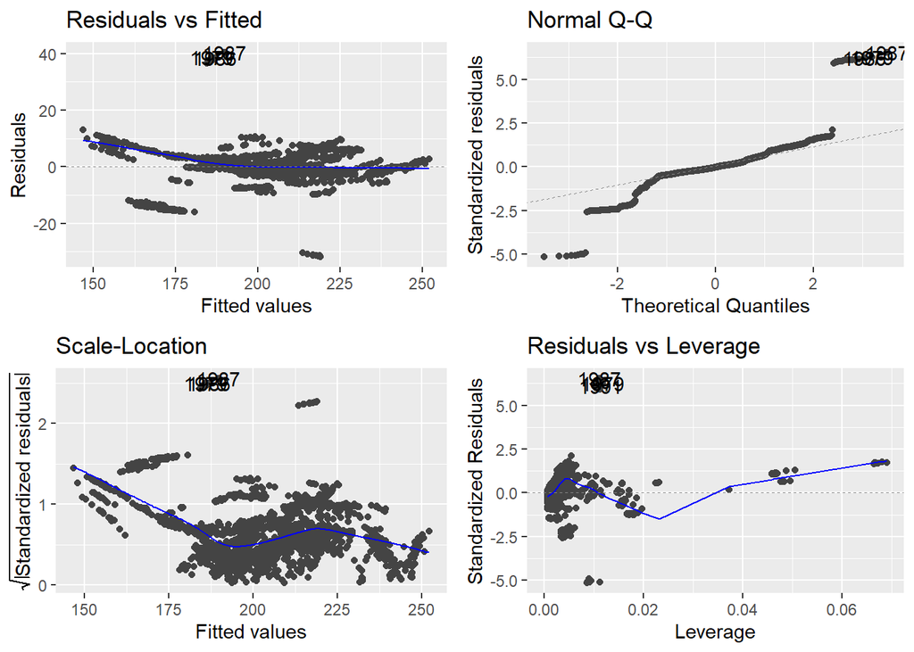

```r
autoplot(model5)
```

Checking multicolinearlity

```r
vif(model5)
```

```
##                 points                   laps           raceDuration
##               1.027706              11.100297              15.220442
##               altitude     fastestLapDuration     averageLapDuration
##               1.103511               3.928247              20.455395
## averagePitstopDuration
##               1.486094
```

averageLapDuration, laps, and raceDuration have very high multi-colinearity since the VIF values are higher than 10. Creating a model without this variables. This indicates that the assumption of multicolinearlity is violated by these three variables,

Fitting model 6: A model that does not include variables with high mutlicolinearity from model 5.

```r
# Fitting a linear model without any of the categorical variables predict Fastest Lap Speed
model6 <- lm(fastestLapSpeed ~ points + altitude + fastestLapDuration + averagePitstopDuration,
             data = f1_df)

tidy(model6)
```

| term | estimate | std.error | statistic | p.value |
| --- | --- | --- | --- | --- |
| (Intercept) | 2.179206e+02 | 3.814285e+00 | 57.132758 | 0.000000e+00 |
| points | 9.421390e-02 | 5.803440e-02 | 1.623415 | 1.046500e-01 |
| altitude | 4.365306e-03 | 1.332458e-03 | 3.276130 | 1.069436e-03 |
| fastestLapDuration | -1.717898e-04 | 3.878366e-05 | -4.429437 | 9.930629e-06 |
| averagePitstopDuration | 9.677020e-06 | 2.485803e-06 | 3.892915 | 1.021202e-04 |

```r
glance(model6)
```

| r.squared | adj.r.squared | sigma | statistic | p.value | df | logLik | AIC | BIC | deviance | df.residual | nobs |
| --- | --- | --- | --- | --- | --- | --- | --- | --- | --- | --- | --- |
| 0.0294426 | 0.02760442 | 20.72917 | 16.01728 | 6.32124e-13 | 4 | -9419.164 | 18850.33 | 18884.28 | 907523.5 | 2112 | 2117 |

```r
vif(model6)
```

```
##                 points               altitude     fastestLapDuration
##               1.021698               1.086218               1.104406
## averagePitstopDuration
##               1.003783
```

The resulting model has a very very low R squared, which suggests that the removed variables make significant contributions to the model. I now consider re-introducing the removed variables with high VIF, one by one.

Fitting Model 7: Since the model has a very low r squared, I return “laps” variable and evaluate the resulting model

```r
# Fitting a linear model
model7 <- lm(fastestLapSpeed ~ points + laps + altitude + fastestLapDuration + averagePitstopDuration,
             data = f1_df)

tidy(model7)
```

| term | estimate | std.error | statistic | p.value |
| --- | --- | --- | --- | --- |
| (Intercept) | 6.394469e+02 | 3.139615e+00 | 203.670486 | 0.000000e+00 |
| points | -2.995163e-02 | 1.761945e-02 | -1.699918 | 8.929361e-02 |
| laps | -3.722877e+00 | 2.577846e-02 | -144.418115 | 0.000000e+00 |
| altitude | 5.543227e-03 | 4.041394e-04 | 13.716126 | 4.441421e-41 |
| fastestLapDuration | -2.320132e-03 | 1.896333e-05 | -122.348309 | 0.000000e+00 |
| averagePitstopDuration | -8.517595e-07 | 7.573171e-07 | -1.124706 | 2.608413e-01 |

```r
glance(model7)
```

| r.squared | adj.r.squared | sigma | statistic | p.value | df | logLik | AIC | BIC | deviance | df.residual | nobs |
| --- | --- | --- | --- | --- | --- | --- | --- | --- | --- | --- | --- |
| 0.910794 | 0.9105827 | 6.285954 | 4310.666 | 0 | 5 | -6892.607 | 13799.21 | 13838.82 | 83412.41 | 2111 | 2117 |

The r squared is high again, suggesting that laps is indeed an important variable.

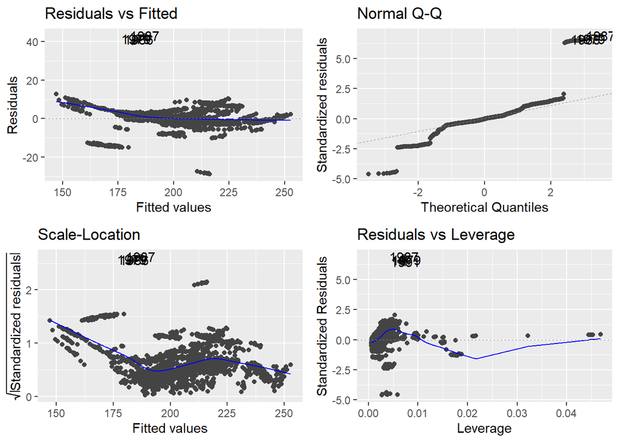

```r
autoplot(model7)
```

```r
vif(model7)
```

```
##                 points                   laps               altitude
##               1.024137               2.770755               1.086661
##     fastestLapDuration averagePitstopDuration
##               2.871323               1.013172
```

The VIF values are less than 10, so this looks good.

Fitting Model 8: How about re-introducing averageLapDuration or raceDuration to see if the resulting model fits well, and if the VIF values are acceptable?

```r
# Fitting a linear model
# reintroducing averageLapDuration
model8 <- lm(fastestLapSpeed ~ points + laps + altitude + fastestLapDuration + averagePitstopDuration + averageLapDuration,
             data = f1_df)

tidy(model8)
```

| term | estimate | std.error | statistic | p.value |
| --- | --- | --- | --- | --- |
| (Intercept) | 6.393842e+02 | 3.141214e+00 | 203.5468581 | 0.000000e+00 |
| points | -3.058501e-02 | 1.764391e-02 | -1.7334598 | 8.316006e-02 |
| laps | -3.721806e+00 | 2.582524e-02 | -144.1150678 | 0.000000e+00 |
| altitude | 5.519486e-03 | 4.055573e-04 | 13.6096339 | 1.705723e-40 |
| fastestLapDuration | -2.312003e-03 | 2.213176e-05 | -104.4653977 | 0.000000e+00 |
| averagePitstopDuration | -4.830822e-07 | 9.172529e-07 | -0.5266620 | 5.984837e-01 |
| averageLapDuration | -7.499093e-06 | 1.052394e-05 | -0.7125746 | 4.761878e-01 |

```r
glance(model8)
```

| r.squared | adj.r.squared | sigma | statistic | p.value | df | logLik | AIC | BIC | deviance | df.residual | nobs |
| --- | --- | --- | --- | --- | --- | --- | --- | --- | --- | --- | --- |
| 0.9108155 | 0.9105619 | 6.286687 | 3591.469 | 0 | 6 | -6892.352 | 13800.7 | 13845.97 | 83392.34 | 2110 | 2117 |

The r squared is significantly high at 0.9108155.

```r
vif(model8)
```

```
##                 points                   laps               altitude
##               1.026742               2.780171               1.094044
##     fastestLapDuration averagePitstopDuration     averageLapDuration
##               3.910059               1.485952               2.396842
```

VIF values are all less than 10 which is strong evidence that multicolinearity assumption is not violated.

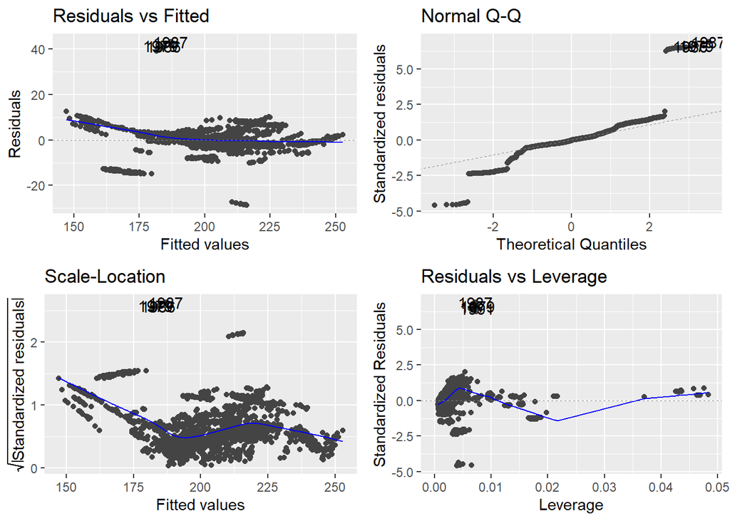

```r
autoplot(model8)
```

I settle on model 8 as the best model to predict “fastestLapSpeed”. The final model from this analysis shows that “fastestLapSpeed” can be predicted using “points”, “lap”, “altitude”, “fastestLapDuration”, “averagePitstopDuration” and “averageLapDuration”. The resuylting model has an r squared value of 0.9108155 which is significantly highy, showing that there is a strong relationship between the response variable with the predictor variables. The model can explain 91.08% of the variation in “fastestLapSpeed” using the 6 predictor variables.